# Chapter 16 - Evaluative uses

Bodo Winter

8/26/2018

## Introduction

This is the analysis for Chapter 16, which explores the evaluative uses of sensory words. In addition, the comparison between different sense operationalizations from Chapter 15 will be continued.

We begin by loading in the data and libraries.

```r
## Libraries:

library(png)        # for plotting sensory modality images
library(car)
library(MASS)
library(tidyverse)
library(stringr)

## Load data:

lyn <- read_csv('../processed-data/lyn_cluster.csv')
war <- read_csv('../raw-data/valence_warriner_2013.csv')
snef <- read_delim('../raw-data/snefjella_kuperman_context_valence.csv',
                   delim = ' ')
SUBTL <- read_csv('../raw-data/frequency_SUBTLEX_POS.csv')

## Load plotting functions:

source('../functions/boxplot_fnc.R')
```

This time, we will use the image data (from freepix.com). So let’s load in images and specify the color values.

```r
## Load in images:

s1 <- readPNG('../figures/sight.png')
s2 <- readPNG('../figures/touch.png')
s3 <- readPNG('../figures/sound.png')
s4 <- readPNG('../figures/taste.png')
s5 <- readPNG('../figures/smell.png')

## Define vector of names:

sense_names <- str_c('s', 1:5)

## Define colors:

mycols <- c('#f37058', '#f79038', '#efbe1b',
            '#425fac', '#30b77d')
```

First, we need to compute the absolute valence measure for the Warriner et al. (2013) and the Snefjella and Kuperman (2016) data.

```r
## Compute absval for Warriner et al. (2013):

war <- mutate(war,
              Val_c = V.Mean.Sum - mean(V.Mean.Sum),
              Val_z = Val_c / sd(Val_c),
              AbsVal = abs(Val_z))

## Compute absval for Snefjella & Kuperman (2016):

snef <- mutate(snef,
               ContextVal_c = Context_Valence - mean(Context_Valence),
               ContextVal_z = ContextVal_c / sd(ContextVal_c),
               ContextAbsVal = abs(ContextVal_z))
```

Merge everything:

```r
## Warriner et al. (2013):
lyn <- left_join(lyn,
                 select(war, Word, Val_z, AbsVal),
                 by = c('Word' = 'Word'))

## Snefjella & Kuperman (2016)

lyn <- left_join(lyn,
    select(snef, Word, ContextVal_c:ContextAbsVal),
    by = c('Word' = 'Word'))
```

Get descriptive stats for the measures:

```r
mean(lyn$Val_z, na.rm = TRUE)
```

```
## [1] 0.00625526
```

```r
range(lyn$Val_z, na.rm = TRUE)
```

```
## [1] -2.442441  2.671720
```

```r
mean(lyn$AbsVal, na.rm = TRUE)
```

```
## [1] 0.9120352
```

```r
range(lyn$AbsVal, na.rm = TRUE)
```

```
## [1] 0.01086126 2.67171986
```

```r
mean(lyn$ContextVal_z, na.rm = TRUE)
```

```
## [1] 0.181299
```

```r
range(lyn$ContextVal_z, na.rm = TRUE)
```

```
## [1] -2.415681  2.157816
```

```r
mean(lyn$ContextAbsVal, na.rm = TRUE)
```

```
## [1] 0.6411576
```

```r
range(lyn$ContextAbsVal, na.rm = TRUE)
```

```
## [1] 0.0005058902 2.4156808883
```

Check overlap between the different datasets:

```r
## Warriner et al. (2013):

sum(!is.na(lyn$AbsVal))
```

```
## [1] 258
```

```r
sum(!is.na(lyn$AbsVal)) / nrow(lyn)
```

```
## [1] 0.6099291
```

```r
## Snefjella & Kuperman (2016):

sum(!is.na(lyn$ContextAbsVal))
```

```
## [1] 412
```

```r
sum(!is.na(lyn$ContextAbsVal)) / nrow(lyn)
```

```
## [1] 0.9739953
```

Check correlation between valence and context valence.

```r
# Valence:

cor.test(lyn$ContextVal_z,
         lyn$Val_z, use = 'complete.obs')
```

```
##
##  Pearson's product-moment correlation
##
## data:  lyn$ContextVal_z and lyn$Val_z
## t = 13.568, df = 256, p-value < 2.2e-16
## alternative hypothesis: true correlation is not equal to 0
## 95 percent confidence interval:
##  0.5696429 0.7126113
## sample estimates:
##       cor
## 0.6467734
```

Biggest mismatch between context and non-context valence:

```r
# Get rid of NAs:

lyn_no_NA <- filter(lyn,
                    complete.cases(ContextVal_z, Val_z))

# Fit model:

valcomp_mdl <- lm(ContextVal_z ~ Val_z, data = lyn_no_NA)

# Extract residuals:

lyn_no_NA$Res <- residuals(valcomp_mdl)

# Check:

arrange(lyn_no_NA, desc(Res)) %>%
  select(Word, Val_z, ContextVal_z, Res)
```

```
## # A tibble: 258 x 4
##    Word       Val_z ContextVal_z   Res
##    <chr>      <dbl>        <dbl> <dbl>
##  1 chewy      0.240        1.78   1.47
##  2 oily      -0.725        1.22   1.36
##  3 smoky     -1.05         1.05   1.34
##  4 spicy      0.985        1.92   1.25
##  5 faint     -0.834        1.05   1.25
##  6 humid     -1.29         0.777  1.19
##  7 tinkling   0.209        1.46   1.15
##  8 tangerine  1.37         1.99   1.13
##  9 chubby    -0.576        1.04   1.11
## 10 crisp      0.130        1.32   1.06
## # ... with 248 more rows
```

```r
arrange(lyn_no_NA, Res) %>%
  select(Word, Val_z, ContextVal_z, Res)
```

```
## # A tibble: 258 x 4
##    Word      Val_z ContextVal_z   Res
##    <chr>     <dbl>        <dbl> <dbl>
##  1 shiny     1.27        -2.42  -3.22
##  2 colossal -0.576       -1.71  -1.64
##  3 slimy    -1.45        -1.87  -1.39
##  4 nutty     0.224       -1.06  -1.37
##  5 grassy    0.734       -0.817 -1.37
##  6 mild      0.656       -0.817 -1.33
##  7 insipid  -0.709       -1.44  -1.31
##  8 soft      1.62        -0.279 -1.25
##  9 rotten   -2.07        -2.03  -1.25
## 10 sore     -1.78        -1.83  -1.19
## # ... with 248 more rows
```

```r
filter(lyn_no_NA,
       Res < 0.1,
       Res > -0.1) %>%
  select(Word, Val_z, ContextVal_z, Res)
```

```
## # A tibble: 38 x 4
##    Word       Val_z ContextVal_z      Res
##    <chr>      <dbl>        <dbl>    <dbl>
##  1 bitter   -1.12        -0.402  -0.0706
##  2 black     0.264        0.370   0.0427
##  3 brown     0.358        0.325  -0.0472
##  4 colorful  1.86         1.13    0.0469
##  5 curved    0.138        0.296   0.0283
##  6 damp     -0.795       -0.230  -0.0544
##  7 dark      0.0127       0.218   0.00985
##  8 enormous  0.483        0.420  -0.0123
##  9 flat     -0.497       -0.0899 -0.0562
## 10 fleshy   -0.136        0.136  -0.00156
## # ... with 28 more rows
```

Compute log-transformed frequencies from SUBTLEX (necessary for ordering clusters).

```r
SUBTL <- SUBTL %>%
  rename(Freq = FREQcount) %>%
  mutate(LogFreq = log10(Freq + 1))

## Merge this into the main data frame:

lyn <- left_join(lyn,
                 select(SUBTL, Word, Freq, LogFreq),
                 by = c('Word' = 'Word'))
```

## Setup for plotting

First, we get ordered clusters, in order of sense, then frequency:

```r
class_order <- lyn %>% group_by(Class, Image) %>%
  summarize(LogFreq = mean(LogFreq, na.rm = TRUE)) %>%
    arrange(Image, desc(LogFreq)) %>% pull(Class)

image_order <- lyn %>% group_by(Class, Image) %>%
    summarize(LogFreq = mean(LogFreq, na.rm = TRUE)) %>%
    arrange(Image, desc(LogFreq)) %>% pull(Image)

color_order <- mycols[as.numeric(as.factor(image_order))]
```

Then we put in the labels into the main data frame:

```r
lyn <- mutate(lyn,
              Clust = factor(Class, levels = class_order))
```

Next, the plotting parameters:

```r
x_fac <- 0.15
x_fac_img <- 0.3
y_fac_img <- 0.036
```

## All boxplots

This will plot all boxplots:

```r
boxplot_fnc(lyn, 'AbsVal',
            ylims = c(0, 3),
            ylab = 'Absolute Valence',
            which_x = 0,
            y_axis = seq(0, 5, 1),
            hlty = 1)
boxplot_fnc(lyn, 'ContextAbsVal',
            ylims = c(0, 2.5),
            ylab = 'Absolute Valence (Contexts)',
            which_x = 0,
            y_axis = seq(0, 2.5, 0.5),
            hlty = 1)
boxplot_fnc(lyn, 'ContextVal_z',
            ylims = c(-2.5, 2.5),
            ylab = 'Valence (Contexts)',
            which_x = 0,
            y_axis = seq(-2.5, 2.5, 0.5),
            hlty = 2)
```

[output not shown]

## Absolute valence (Warriner et al., 2013)

For each of the emotional valence measures, we now compare a model with the clusters, with the dominant modality classifications, and with the continuous measures.

```r
## Clusters:

summary(absval.class <- lm(AbsVal ~ Class, lyn))
```

```
##
## Call:
## lm(formula = AbsVal ~ Class, data = lyn)
##
## Residuals:
##      Min       1Q   Median       3Q      Max
## -1.21145 -0.38627 -0.00316  0.36433  1.45487
##
## Coefficients:
##                         Estimate Std. Error t value Pr(>|t|)
## (Intercept)              0.91127    0.17753   5.133 5.79e-07 ***
## Classgross surface      -0.12213    0.19952  -0.612   0.5410
## Classimpression-related  0.35992    0.21569   1.669   0.0965 .
## Classmotion & touch     -0.07399    0.21005  -0.352   0.7250
## Classmultimodal          0.18884    0.19247   0.981   0.3275
## Classpure sight         -0.10229    0.20195  -0.507   0.6129
## Classshape & extent     -0.40994    0.21130  -1.940   0.0535 .
## Classskin & temperature -0.04998    0.23613  -0.212   0.8325
## Classsmell               0.43787    0.28990   1.510   0.1322
## Classsound 1            -0.06120    0.26629  -0.230   0.8184
## Classsound 2            -0.41642    0.27665  -1.505   0.1336
## Classtaste               0.20730    0.22918   0.905   0.3666
## ---
## Signif. codes:  0 '***' 0.001 '**' 0.01 '*' 0.05 '.' 0.1 ' ' 1
##
## Residual standard error: 0.5614 on 246 degrees of freedom
##   (165 observations deleted due to missingness)
## Multiple R-squared:  0.1428, Adjusted R-squared:  0.1045
## F-statistic: 3.726 on 11 and 246 DF,  p-value: 6.217e-05
```

```r
anova(absval.class)
```

```
## Analysis of Variance Table
##
## Response: AbsVal
##            Df Sum Sq Mean Sq F value    Pr(>F)
## Class      11 12.917 1.17425   3.726 6.217e-05 ***
## Residuals 246 77.528 0.31515
## ---
## Signif. codes:  0 '***' 0.001 '**' 0.01 '*' 0.05 '.' 0.1 ' ' 1
```

```r
## Dominant modality:

summary(absval.mod <- lm(AbsVal ~ DominantModality, lyn))
```

```
##
## Call:
## lm(formula = AbsVal ~ DominantModality, data = lyn)
##
## Residuals:
##      Min       1Q   Median       3Q      Max
## -1.01027 -0.47668 -0.04338  0.40548  1.79774
##
## Coefficients:
##                           Estimate Std. Error t value Pr(>|t|)
## (Intercept)                 0.7211     0.1471   4.902  1.7e-06 ***
## DominantModalityGustatory   0.3175     0.1899   1.672   0.0958 .
## DominantModalityHaptic      0.2094     0.1679   1.248   0.2133
## DominantModalityOlfactory   0.5324     0.2154   2.472   0.0141 *
## DominantModalityVisual      0.1528     0.1547   0.988   0.3241
## ---
## Signif. codes:  0 '***' 0.001 '**' 0.01 '*' 0.05 '.' 0.1 ' ' 1
##
## Residual standard error: 0.5885 on 253 degrees of freedom
##   (165 observations deleted due to missingness)
## Multiple R-squared:  0.03137,    Adjusted R-squared:  0.01605
## F-statistic: 2.048 on 4 and 253 DF,  p-value: 0.08817
```

```r
anova(absval.mod)
```

```
## Analysis of Variance Table
##
## Response: AbsVal
##                   Df Sum Sq Mean Sq F value  Pr(>F)
## DominantModality   4  2.837 0.70923  2.0482 0.08817 .
## Residuals        253 87.607 0.34627
## ---
## Signif. codes:  0 '***' 0.001 '**' 0.01 '*' 0.05 '.' 0.1 ' ' 1
```

```r
## Descriptive means:

lyn %>% group_by(DominantModality) %>%
  summarize(AbsValM = mean(AbsVal, na.rm = TRUE),
            AbsValSD = sd(AbsVal, na.rm = TRUE)) %>%
  mutate(AbsValM = round(AbsValM, 1),
         AbsValSD = round(AbsValSD, 1))
```

```
## # A tibble: 5 x 3
##   DominantModality AbsValM AbsValSD
##   <chr>              <dbl>    <dbl>
## 1 Auditory             0.7      0.5
## 2 Gustatory            1        0.6
## 3 Haptic               0.9      0.5
## 4 Olfactory            1.3      0.5
## 5 Visual               0.9      0.6
```

```r
## Continuous model:

summary(absval.cont <- lm(AbsVal ~ VisualStrengthMean +
                            GustatoryStrengthMean +
                            OlfactoryStrengthMean +
                            HapticStrengthMean +
                            AuditoryStrengthMean, lyn))
```

```
##
## Call:
## lm(formula = AbsVal ~ VisualStrengthMean + GustatoryStrengthMean +
##     OlfactoryStrengthMean + HapticStrengthMean + AuditoryStrengthMean,
##     data = lyn)
##
## Residuals:
##      Min       1Q   Median       3Q      Max
## -1.17596 -0.41366 -0.05215  0.35740  1.60938
##
## Coefficients:
##                       Estimate Std. Error t value Pr(>|t|)
## (Intercept)            0.53563    0.18769   2.854  0.00468 **
## VisualStrengthMean     0.04393    0.03803   1.155  0.24910
## GustatoryStrengthMean -0.03624    0.03539  -1.024  0.30682
## OlfactoryStrengthMean  0.18685    0.03721   5.021 9.74e-07 ***
## HapticStrengthMean    -0.01013    0.02285  -0.443  0.65806
## AuditoryStrengthMean   0.04147    0.03123   1.328  0.18547
## ---
## Signif. codes:  0 '***' 0.001 '**' 0.01 '*' 0.05 '.' 0.1 ' ' 1
##
## Residual standard error: 0.5572 on 252 degrees of freedom
##   (165 observations deleted due to missingness)
## Multiple R-squared:  0.1349, Adjusted R-squared:  0.1177
## F-statistic:  7.86 on 5 and 252 DF,  p-value: 6.773e-07
```

```r
summary(absval.cont.null <- lm(AbsVal ~ 1, lyn))
```

```
##
## Call:
## lm(formula = AbsVal ~ 1, data = lyn)
##
## Residuals:
##      Min       1Q   Median       3Q      Max
## -0.90117 -0.48998 -0.03836  0.39305  1.75968
##
## Coefficients:
##             Estimate Std. Error t value Pr(>|t|)
## (Intercept)  0.91204    0.03693   24.69   <2e-16 ***
## ---
## Signif. codes:  0 '***' 0.001 '**' 0.01 '*' 0.05 '.' 0.1 ' ' 1
##
## Residual standard error: 0.5932 on 257 degrees of freedom
##   (165 observations deleted due to missingness)
```

```r
anova(absval.cont.null, absval.cont, test = 'F')
```

```
## Analysis of Variance Table
##
## Model 1: AbsVal ~ 1
## Model 2: AbsVal ~ VisualStrengthMean + GustatoryStrengthMean + OlfactoryStrengthMean +
##     HapticStrengthMean + AuditoryStrengthMean
##   Res.Df    RSS Df Sum of Sq      F    Pr(>F)
## 1    257 90.444
## 2    252 78.243  5    12.201 7.8596 6.773e-07 ***
## ---
## Signif. codes:  0 '***' 0.001 '**' 0.01 '*' 0.05 '.' 0.1 ' ' 1
```

```r
anova(absval.cont)
```

```
## Analysis of Variance Table
##
## Response: AbsVal
##                        Df Sum Sq Mean Sq F value    Pr(>F)
## VisualStrengthMean      1  0.391  0.3906  1.2579  0.263123
## GustatoryStrengthMean   1  2.765  2.7653  8.9063  0.003121 **
## OlfactoryStrengthMean   1  8.435  8.4350 27.1668 3.888e-07 ***
## HapticStrengthMean      1  0.063  0.0634  0.2041  0.651810
## AuditoryStrengthMean    1  0.547  0.5473  1.7628  0.185471
## Residuals             252 78.243  0.3105
## ---
## Signif. codes:  0 '***' 0.001 '**' 0.01 '*' 0.05 '.' 0.1 ' ' 1
```

```r
## Check collinearity:

vif(absval.cont)
```

```
##    VisualStrengthMean GustatoryStrengthMean OlfactoryStrengthMean
##              1.430950              2.257153              2.316923
##    HapticStrengthMean  AuditoryStrengthMean
##              1.152712              1.236768
```

```r
## BICs:

BIC(absval.class);BIC(absval.mod);BIC(absval.cont)
```

```
## [1] 494.1605
```

```
## [1] 486.8257
```

```
## [1] 463.2121
```

## Context absolute valence (Snefjella & Kuperman, 2016):

Next, we repeat these analyses for the context-based valence from Snefjella & Kuperman (2016):

```r
## Cluster model:

summary(conabs.class <- lm(ContextAbsVal ~ Class, lyn))
```

```
##
## Call:
## lm(formula = ContextAbsVal ~ Class, data = lyn)
##
## Residuals:
##      Min       1Q   Median       3Q      Max
## -1.00921 -0.36125 -0.08458  0.32941  1.94536
##
## Coefficients:
##                         Estimate Std. Error t value Pr(>|t|)
## (Intercept)              1.09089    0.10461  10.428  < 2e-16 ***
## Classgross surface      -0.70994    0.12480  -5.689 2.48e-08 ***
## Classimpression-related -0.33655    0.13773  -2.444 0.014976 *
## Classmotion & touch     -0.60072    0.13024  -4.612 5.37e-06 ***
## Classmultimodal         -0.37983    0.11953  -3.178 0.001600 **
## Classpure sight         -0.44196    0.12968  -3.408 0.000721 ***
## Classshape & extent     -0.62056    0.13084  -4.743 2.93e-06 ***
## Classskin & temperature -0.46249    0.16430  -2.815 0.005121 **
## Classsmell              -0.08034    0.18714  -0.429 0.667919
## Classsound 1            -0.49117    0.13590  -3.614 0.000340 ***
## Classsound 2            -0.47557    0.13590  -3.499 0.000519 ***
## Classtaste              -0.21851    0.14093  -1.550 0.121814
## ---
## Signif. codes:  0 '***' 0.001 '**' 0.01 '*' 0.05 '.' 0.1 ' ' 1
##
## Residual standard error: 0.4907 on 400 degrees of freedom
##   (11 observations deleted due to missingness)
## Multiple R-squared:  0.1241, Adjusted R-squared:    0.1
## F-statistic: 5.152 on 11 and 400 DF,  p-value: 1.401e-07
```

```r
anova(conabs.class)
```

```
## Analysis of Variance Table
##
## Response: ContextAbsVal
##            Df Sum Sq Mean Sq F value    Pr(>F)
## Class      11 13.646 1.24053  5.1523 1.401e-07 ***
## Residuals 400 96.309 0.24077
## ---
## Signif. codes:  0 '***' 0.001 '**' 0.01 '*' 0.05 '.' 0.1 ' ' 1
```

```r
## Dominant modality model:

summary(conabs.mod <- lm(ContextAbsVal ~ DominantModality, lyn))
```

```
##
## Call:
## lm(formula = ContextAbsVal ~ DominantModality, data = lyn)
##
## Residuals:
##     Min      1Q  Median      3Q     Max
## -0.9216 -0.3960 -0.1188  0.3333  1.8371
##
## Coefficients:
##                           Estimate Std. Error t value Pr(>|t|)
## (Intercept)                0.60727    0.06049  10.039  < 2e-16 ***
## DominantModalityGustatory  0.39602    0.09586   4.131 4.38e-05 ***
## DominantModalityHaptic    -0.06147    0.08494  -0.724   0.4697
## DominantModalityOlfactory  0.26315    0.11844   2.222   0.0268 *
## DominantModalityVisual    -0.02863    0.06981  -0.410   0.6819
## ---
## Signif. codes:  0 '***' 0.001 '**' 0.01 '*' 0.05 '.' 0.1 ' ' 1
##
## Residual standard error: 0.4988 on 407 degrees of freedom
##   (11 observations deleted due to missingness)
## Multiple R-squared:  0.07893,    Adjusted R-squared:  0.06988
## F-statistic: 8.719 on 4 and 407 DF,  p-value: 9.242e-07
```

```r
anova(conabs.mod)
```

```
## Analysis of Variance Table
##
## Response: ContextAbsVal
##                   Df  Sum Sq Mean Sq F value    Pr(>F)
## DominantModality   4   8.679 2.16964  8.7191 9.242e-07 ***
## Residuals        407 101.276 0.24884
## ---
## Signif. codes:  0 '***' 0.001 '**' 0.01 '*' 0.05 '.' 0.1 ' ' 1
```

```r
## Descriptive means:

lyn %>% group_by(DominantModality) %>%
  summarize(ContextAbsValM = mean(ContextAbsVal,
                                 na.rm = TRUE),
            ContextAbsValSD = sd(ContextAbsVal,
                                   na.rm = TRUE)) %>%
  mutate(ContextAbsValM = round(ContextAbsValM, 1),
         ContextAbsValSD = round(ContextAbsValSD, 1))
```

```
## # A tibble: 5 x 3
##   DominantModality ContextAbsValM ContextAbsValSD
##   <chr>                     <dbl>           <dbl>
## 1 Auditory                    0.6             0.5
## 2 Gustatory                   1               0.6
## 3 Haptic                      0.5             0.4
## 4 Olfactory                   0.9             0.6
## 5 Visual                      0.6             0.5
```

```r
## Continuous model:

summary(conabs.cont <- lm(ContextAbsVal ~ VisualStrengthMean +
                            GustatoryStrengthMean +
                            OlfactoryStrengthMean +
                            HapticStrengthMean +
                            AuditoryStrengthMean, lyn))
```

```
##
## Call:
## lm(formula = ContextAbsVal ~ VisualStrengthMean + GustatoryStrengthMean +
##     OlfactoryStrengthMean + HapticStrengthMean + AuditoryStrengthMean,
##     data = lyn)
##
## Residuals:
##      Min       1Q   Median       3Q      Max
## -1.08925 -0.36628 -0.08131  0.32048  1.83691
##
## Coefficients:
##                       Estimate Std. Error t value Pr(>|t|)
## (Intercept)            1.03356    0.12413   8.327 1.29e-15 ***
## VisualStrengthMean    -0.06364    0.02516  -2.530   0.0118 *
## GustatoryStrengthMean  0.03146    0.02551   1.233   0.2183
## OlfactoryStrengthMean  0.02659    0.02795   0.951   0.3420
## HapticStrengthMean    -0.07421    0.01671  -4.442 1.15e-05 ***
## AuditoryStrengthMean  -0.04759    0.01867  -2.549   0.0112 *
## ---
## Signif. codes:  0 '***' 0.001 '**' 0.01 '*' 0.05 '.' 0.1 ' ' 1
##
## Residual standard error: 0.4801 on 406 degrees of freedom
##   (11 observations deleted due to missingness)
## Multiple R-squared:  0.1488, Adjusted R-squared:  0.1383
## F-statistic: 14.19 on 5 and 406 DF,  p-value: 8.279e-13
```

```r
summary(conabs.cont.null <- lm(ContextAbsVal ~ 1, lyn))
```

```
##
## Call:
## lm(formula = ContextAbsVal ~ 1, data = lyn)
##
## Residuals:
##     Min      1Q  Median      3Q     Max
## -0.6407 -0.4311 -0.1660  0.3712  1.7745
##
## Coefficients:
##             Estimate Std. Error t value Pr(>|t|)
## (Intercept)  0.64116    0.02548   25.16   <2e-16 ***
## ---
## Signif. codes:  0 '***' 0.001 '**' 0.01 '*' 0.05 '.' 0.1 ' ' 1
##
## Residual standard error: 0.5172 on 411 degrees of freedom
##   (11 observations deleted due to missingness)
```

```r
summary(conabs.cont)$r.squared
```

```
## [1] 0.1487706
```

```r
anova(conabs.cont.null, conabs.cont, test = 'Chisq')
```

```
## Analysis of Variance Table
##
## Model 1: ContextAbsVal ~ 1
## Model 2: ContextAbsVal ~ VisualStrengthMean + GustatoryStrengthMean +
##     OlfactoryStrengthMean + HapticStrengthMean + AuditoryStrengthMean
##   Res.Df     RSS Df Sum of Sq  Pr(>Chi)
## 1    411 109.955
## 2    406  93.597  5    16.358 6.477e-14 ***
## ---
## Signif. codes:  0 '***' 0.001 '**' 0.01 '*' 0.05 '.' 0.1 ' ' 1
```

```r
anova(conabs.cont)
```

```
## Analysis of Variance Table
##
## Response: ContextAbsVal
##                        Df Sum Sq Mean Sq F value    Pr(>F)
## VisualStrengthMean      1  5.106  5.1063 22.1497 3.465e-06 ***
## GustatoryStrengthMean   1  4.390  4.3901 19.0432 1.623e-05 ***
## OlfactoryStrengthMean   1  1.668  1.6685  7.2374  0.007435 **
## HapticStrengthMean      1  3.695  3.6953 16.0293 7.416e-05 ***
## AuditoryStrengthMean    1  1.498  1.4979  6.4976  0.011169 *
## Residuals             406 93.597  0.2305
## ---
## Signif. codes:  0 '***' 0.001 '**' 0.01 '*' 0.05 '.' 0.1 ' ' 1
```

```r
## Collinearity:

vif(conabs.cont)
```

```
##    VisualStrengthMean GustatoryStrengthMean OlfactoryStrengthMean
##              1.516547              2.675953              2.863319
##    HapticStrengthMean  AuditoryStrengthMean
##              1.280253              1.601755
```

```r
## BIC:

BIC(conabs.class);BIC(conabs.mod);BIC(conabs.cont)
```

```
## [1] 648.6526
```

```
## [1] 627.225
```

```
## [1] 600.7573
```

## Valence (positve/negative) (Warriner et al., 2013)

The absolute valence measure looks at “emotionality” regardless of whether it’s positive or negative.

```r
## Cluster model:

summary(val.class <- lm(Val_z ~ Class, lyn))
```

```
##
## Call:
## lm(formula = Val_z ~ Class, data = lyn)
##
## Residuals:
##      Min       1Q   Median       3Q      Max
## -2.48596 -0.79717  0.00237  0.74784  2.37368
##
## Coefficients:
##                          Estimate Std. Error t value Pr(>|t|)
## (Intercept)             -0.347360   0.339927  -1.022   0.3078
## Classgross surface       0.113983   0.382045   0.298   0.7657
## Classimpression-related  0.645396   0.413006   1.563   0.1194
## Classmotion & touch      0.226686   0.402207   0.564   0.5735
## Classmultimodal          0.208934   0.368541   0.567   0.5713
## Classpure sight          0.828813   0.386698   2.143   0.0331 *
## Classshape & extent      0.474746   0.404594   1.173   0.2418
## Classskin & temperature -0.008025   0.452145  -0.018   0.9859
## Classsmell               0.221457   0.555098   0.399   0.6903
## Classsound 1             0.010001   0.509890   0.020   0.9844
## Classsound 2             0.382441   0.529738   0.722   0.4710
## Classtaste               0.814448   0.438844   1.856   0.0647 .
## ---
## Signif. codes:  0 '***' 0.001 '**' 0.01 '*' 0.05 '.' 0.1 ' ' 1
##
## Residual standard error: 1.075 on 246 degrees of freedom
##   (165 observations deleted due to missingness)
## Multiple R-squared:  0.06814,    Adjusted R-squared:  0.02648
## F-statistic: 1.635 on 11 and 246 DF,  p-value: 0.0894
```

```r
anova(val.class)
```

```
## Analysis of Variance Table
##
## Response: Val_z
##            Df  Sum Sq Mean Sq F value Pr(>F)
## Class      11  20.787  1.8897  1.6354 0.0894 .
## Residuals 246 284.254  1.1555
## ---
## Signif. codes:  0 '***' 0.001 '**' 0.01 '*' 0.05 '.' 0.1 ' ' 1
```

```r
## Dominant modality model:

summary(val.mod <- lm(Val_z ~ DominantModality, lyn))
```

```
##
## Call:
## lm(formula = Val_z ~ DominantModality, data = lyn)
##
## Residuals:
##      Min       1Q   Median       3Q      Max
## -2.59983 -0.79759 -0.00745  0.77696  2.51433
##
## Coefficients:
##                           Estimate Std. Error t value Pr(>|t|)
## (Intercept)               -0.23294    0.26767  -0.870    0.385
## DominantModalityGustatory  0.46033    0.34556   1.332    0.184
## DominantModalityHaptic    -0.07258    0.30541  -0.238    0.812
## DominantModalityOlfactory -0.31634    0.39183  -0.807    0.420
## DominantModalityVisual     0.39033    0.28150   1.387    0.167
##
## Residual standard error: 1.071 on 253 degrees of freedom
##   (165 observations deleted due to missingness)
## Multiple R-squared:  0.04921,    Adjusted R-squared:  0.03418
## F-statistic: 3.274 on 4 and 253 DF,  p-value: 0.01221
```

```r
anova(val.mod)
```

```
## Analysis of Variance Table
##
## Response: Val_z
##                   Df  Sum Sq Mean Sq F value  Pr(>F)
## DominantModality   4  15.011  3.7527  3.2736 0.01221 *
## Residuals        253 290.030  1.1464
## ---
## Signif. codes:  0 '***' 0.001 '**' 0.01 '*' 0.05 '.' 0.1 ' ' 1
```

```r
## Descriptive means:

lyn %>% group_by(DominantModality) %>%
  summarize(Val_zM = mean(Val_z, na.rm = TRUE),
            Val_zSD = sd(Val_z, na.rm = TRUE)) %>%
  mutate(Val_zM = round(Val_zM, 1),
         Val_zSD = round(Val_zSD, 1))
```

```
## # A tibble: 5 x 3
##   DominantModality Val_zM Val_zSD
##   <chr>             <dbl>   <dbl>
## 1 Auditory           -0.2     0.9
## 2 Gustatory           0.2     1.2
## 3 Haptic             -0.3     1
## 4 Olfactory          -0.5     1.3
## 5 Visual              0.2     1.1
```

```r
## Average valence per modality:

aggregate(Val_z ~ DominantModality, lyn, mean)
```

```
##   DominantModality      Val_z
## 1         Auditory -0.2329390
## 2        Gustatory  0.2273943
## 3           Haptic -0.3055219
## 4        Olfactory -0.5492824
## 5           Visual  0.1573909
```

```r
## Continuous model:

summary(val.cont <- lm(Val_z ~ VisualStrengthMean +
                          GustatoryStrengthMean +
                          OlfactoryStrengthMean +
                          HapticStrengthMean +
                          AuditoryStrengthMean, lyn))
```

```
##
## Call:
## lm(formula = Val_z ~ VisualStrengthMean + GustatoryStrengthMean +
##     OlfactoryStrengthMean + HapticStrengthMean + AuditoryStrengthMean,
##     data = lyn)
##
## Residuals:
##      Min       1Q   Median       3Q      Max
## -2.62361 -0.74468  0.00958  0.79938  2.38543
##
## Coefficients:
##                       Estimate Std. Error t value Pr(>|t|)
## (Intercept)           -0.69072    0.35811  -1.929  0.05488 .
## VisualStrengthMean     0.23707    0.07255   3.267  0.00124 **
## GustatoryStrengthMean  0.13083    0.06752   1.938  0.05379 .
## OlfactoryStrengthMean -0.09142    0.07100  -1.288  0.19908
## HapticStrengthMean    -0.13468    0.04360  -3.089  0.00224 **
## AuditoryStrengthMean   0.04866    0.05959   0.817  0.41491
## ---
## Signif. codes:  0 '***' 0.001 '**' 0.01 '*' 0.05 '.' 0.1 ' ' 1
##
## Residual standard error: 1.063 on 252 degrees of freedom
##   (165 observations deleted due to missingness)
## Multiple R-squared:  0.06627,    Adjusted R-squared:  0.04774
## F-statistic: 3.577 on 5 and 252 DF,  p-value: 0.003832
```

```r
val.cont.null <- lm(Val_z ~ 1, lyn)
anova(val.cont.null, val.cont, test = 'F')
```

```
## Analysis of Variance Table
##
## Model 1: Val_z ~ 1
## Model 2: Val_z ~ VisualStrengthMean + GustatoryStrengthMean + OlfactoryStrengthMean +
##     HapticStrengthMean + AuditoryStrengthMean
##   Res.Df    RSS Df Sum of Sq     F   Pr(>F)
## 1    257 305.04
## 2    252 284.83  5    20.215 3.577 0.003832 **
## ---
## Signif. codes:  0 '***' 0.001 '**' 0.01 '*' 0.05 '.' 0.1 ' ' 1
```

```r
anova(val.cont)
```

```
## Analysis of Variance Table
##
## Response: Val_z
##                        Df  Sum Sq Mean Sq F value   Pr(>F)
## VisualStrengthMean      1   6.911  6.9113  6.1148 0.014066 *
## GustatoryStrengthMean   1   1.338  1.3380  1.1838 0.277626
## OlfactoryStrengthMean   1   0.392  0.3918  0.3466 0.556557
## HapticStrengthMean      1  10.820 10.8196  9.5727 0.002198 **
## AuditoryStrengthMean    1   0.754  0.7538  0.6669 0.414910
## Residuals             252 284.826  1.1303
## ---
## Signif. codes:  0 '***' 0.001 '**' 0.01 '*' 0.05 '.' 0.1 ' ' 1
```

```r
## Check collinearity:

vif(val.cont)
```

```
##    VisualStrengthMean GustatoryStrengthMean OlfactoryStrengthMean
##              1.430950              2.257153              2.316923
##    HapticStrengthMean  AuditoryStrengthMean
##              1.152712              1.236768
```

```r
## BICs:

BIC(val.class);BIC(val.mod);BIC(val.cont)
```

```
## [1] 829.3629
```

```
## [1] 795.6824
```

```
## [1] 796.5643
```

## Context valence (positve/negative) (Snefjella & Kuperman, 2016):

The absolute valence measure looks at “emotionality” regardless of whether it’s positive or negative.

```r
## Cluster model:

summary(conval.class <- lm(ContextVal_z ~ Class, lyn))
```

```
##
## Call:
## lm(formula = ContextVal_z ~ Class, data = lyn)
##
## Residuals:
##      Min       1Q   Median       3Q      Max
## -2.49268 -0.45008 -0.04372  0.51697  1.98004
##
## Coefficients:
##                         Estimate Std. Error t value Pr(>|t|)
## (Intercept)              0.32438    0.16579   1.957   0.0511 .
## Classgross surface      -0.32032    0.19778  -1.620   0.1061
## Classimpression-related -0.09801    0.21827  -0.449   0.6537
## Classmotion & touch     -0.22423    0.20641  -1.086   0.2780
## Classmultimodal         -0.14661    0.18943  -0.774   0.4394
## Classpure sight          0.22966    0.20551   1.117   0.2645
## Classshape & extent     -0.24738    0.20735  -1.193   0.2335
## Classskin & temperature -0.21539    0.26039  -0.827   0.4086
## Classsmell              -0.20430    0.29658  -0.689   0.4913
## Classsound 1            -0.63258    0.21537  -2.937   0.0035 **
## Classsound 2            -0.14140    0.21537  -0.657   0.5118
## Classtaste               0.38686    0.22335   1.732   0.0840 .
## ---
## Signif. codes:  0 '***' 0.001 '**' 0.01 '*' 0.05 '.' 0.1 ' ' 1
##
## Residual standard error: 0.7776 on 400 degrees of freedom
##   (11 observations deleted due to missingness)
## Multiple R-squared:  0.08991,    Adjusted R-squared:  0.06488
## F-statistic: 3.592 on 11 and 400 DF,  p-value: 7.516e-05
```

```r
anova(conval.class)
```

```
## Analysis of Variance Table
##
## Response: ContextVal_z
##            Df  Sum Sq Mean Sq F value    Pr(>F)
## Class      11  23.896 2.17233  3.5924 7.516e-05 ***
## Residuals 400 241.883 0.60471
## ---
## Signif. codes:  0 '***' 0.001 '**' 0.01 '*' 0.05 '.' 0.1 ' ' 1
```

```r
## Dominant modality model:

summary(conval.mod <- lm(ContextVal_z ~ DominantModality, lyn))
```

```
##
## Call:
## lm(formula = ContextVal_z ~ DominantModality, data = lyn)
##
## Residuals:
##      Min       1Q   Median       3Q      Max
## -2.65093 -0.44123 -0.02518  0.50161  2.11622
##
## Coefficients:
##                           Estimate Std. Error t value Pr(>|t|)
## (Intercept)               -0.05992    0.09364  -0.640  0.52260
## DominantModalityGustatory  0.78912    0.14839   5.318 1.74e-07 ***
## DominantModalityHaptic     0.09776    0.13148   0.744  0.45758
## DominantModalityOlfactory -0.14503    0.18334  -0.791  0.42939
## DominantModalityVisual     0.29517    0.10806   2.731  0.00658 **
## ---
## Signif. codes:  0 '***' 0.001 '**' 0.01 '*' 0.05 '.' 0.1 ' ' 1
##
## Residual standard error: 0.7722 on 407 degrees of freedom
##   (11 observations deleted due to missingness)
## Multiple R-squared:  0.08685,    Adjusted R-squared:  0.07788
## F-statistic: 9.678 on 4 and 407 DF,  p-value: 1.743e-07
```

```r
anova(conval.mod)
```

```
## Analysis of Variance Table
##
## Response: ContextVal_z
##                   Df  Sum Sq Mean Sq F value    Pr(>F)
## DominantModality   4  23.083  5.7708  9.6777 1.743e-07 ***
## Residuals        407 242.696  0.5963
## ---
## Signif. codes:  0 '***' 0.001 '**' 0.01 '*' 0.05 '.' 0.1 ' ' 1
```

```r
## Descriptive means:

lyn %>% group_by(DominantModality) %>%
  summarize(ContextVal_zM = mean(ContextVal_z, na.rm = TRUE),
            ContextVal_zSD = sd(ContextVal_z, na.rm = TRUE)) %>%
  mutate(ContextVal_zM = round(ContextVal_zM, 1),
         ContextVal_zSD = round(ContextVal_zSD, 1))
```

```
## # A tibble: 5 x 3
##   DominantModality ContextVal_zM ContextVal_zSD
##   <chr>                    <dbl>          <dbl>
## 1 Auditory                  -0.1            0.8
## 2 Gustatory                  0.7            0.9
## 3 Haptic                     0              0.7
## 4 Olfactory                 -0.2            1
## 5 Visual                     0.2            0.7
```

```r
## Average valence per modality:

aggregate(Val_z ~ DominantModality, lyn, mean)
```

```
##   DominantModality      Val_z
## 1         Auditory -0.2329390
## 2        Gustatory  0.2273943
## 3           Haptic -0.3055219
## 4        Olfactory -0.5492824
## 5           Visual  0.1573909
```

```r
## Continuous model:

summary(conval.cont <- lm(ContextVal_z ~ VisualStrengthMean +
                          GustatoryStrengthMean +
                          OlfactoryStrengthMean +
                          HapticStrengthMean +
                          AuditoryStrengthMean, lyn))
```

```
##
## Call:
## lm(formula = ContextVal_z ~ VisualStrengthMean + GustatoryStrengthMean +
##     OlfactoryStrengthMean + HapticStrengthMean + AuditoryStrengthMean,
##     data = lyn)
##
## Residuals:
##      Min       1Q   Median       3Q      Max
## -2.71313 -0.41819 -0.02084  0.53711  1.92423
##
## Coefficients:
##                       Estimate Std. Error t value Pr(>|t|)
## (Intercept)            0.11769    0.19955   0.590  0.55567
## VisualStrengthMean     0.07468    0.04044   1.847  0.06551 .
## GustatoryStrengthMean  0.17696    0.04101   4.315 2.01e-05 ***
## OlfactoryStrengthMean -0.10365    0.04493  -2.307  0.02157 *
## HapticStrengthMean    -0.10151    0.02686  -3.780  0.00018 ***
## AuditoryStrengthMean  -0.05325    0.03002  -1.774  0.07682 .
## ---
## Signif. codes:  0 '***' 0.001 '**' 0.01 '*' 0.05 '.' 0.1 ' ' 1
##
## Residual standard error: 0.7719 on 406 degrees of freedom
##   (11 observations deleted due to missingness)
## Multiple R-squared:  0.08987,    Adjusted R-squared:  0.07866
## F-statistic: 8.018 on 5 and 406 DF,  p-value: 3.175e-07
```

```r
conval.cont.null <- lm(ContextVal_z ~ 1, lyn)
anova(conval.cont.null, conval.cont, test = 'F')
```

```
## Analysis of Variance Table
##
## Model 1: ContextVal_z ~ 1
## Model 2: ContextVal_z ~ VisualStrengthMean + GustatoryStrengthMean + OlfactoryStrengthMean +
##     HapticStrengthMean + AuditoryStrengthMean
##   Res.Df    RSS Df Sum of Sq      F    Pr(>F)
## 1    411 265.78
## 2    406 241.89  5    23.886 8.0182 3.175e-07 ***
## ---
## Signif. codes:  0 '***' 0.001 '**' 0.01 '*' 0.05 '.' 0.1 ' ' 1
```

```r
anova(conval.cont)
```

```
## Analysis of Variance Table
##
## Response: ContextVal_z
##                        Df  Sum Sq Mean Sq F value    Pr(>F)
## VisualStrengthMean      1   0.317  0.3172  0.5323 0.4660512
## GustatoryStrengthMean   1  13.689 13.6891 22.9762 2.305e-06 ***
## OlfactoryStrengthMean   1   0.750  0.7497  1.2583 0.2626333
## HapticStrengthMean      1   7.255  7.2552 12.1774 0.0005367 ***
## AuditoryStrengthMean    1   1.875  1.8749  3.1470 0.0768182 .
## Residuals             406 241.893  0.5958
## ---
## Signif. codes:  0 '***' 0.001 '**' 0.01 '*' 0.05 '.' 0.1 ' ' 1
```

```r
## Check collinearity:

vif(conval.cont)
```

```
##    VisualStrengthMean GustatoryStrengthMean OlfactoryStrengthMean
##              1.516547              2.675953              2.863319
##    HapticStrengthMean  AuditoryStrengthMean
##              1.280253              1.601755
```

```r
## BICs:

BIC(conval.class);BIC(conval.mod);BIC(conval.cont)
```

```
## [1] 1028.061
```

```
## [1] 987.2947
```

```
## [1] 991.9507
```

## Taste versus smell post-hoc comparison

Taste is predicted to be more positive than smell.

```r
chemsense <- filter(lyn,
                    DominantModality %in% c('Gustatory', 'Olfactory'))

wilcox.test(Val_z ~ DominantModality,
            data = chemsense, paired = FALSE)
```

```
##
##  Wilcoxon rank sum test with continuity correction
##
## data:  Val_z by DominantModality
## W = 224.5, p-value = 0.09009
## alternative hypothesis: true location shift is not equal to 0
```

```r
t.test(Val_z ~ DominantModality,
       data = chemsense, paired = FALSE)
```

```
##
##  Welch Two Sample t-test
##
## data:  Val_z by DominantModality
## t = 1.854, df = 26.543, p-value = 0.07488
## alternative hypothesis: true difference in means is not equal to 0
## 95 percent confidence interval:
##  -0.08357089  1.63692431
## sample estimates:
## mean in group Gustatory mean in group Olfactory
##               0.2273943              -0.5492824
```

```r
wilcox.test(ContextVal_z ~ DominantModality,
            data = chemsense, paired = FALSE)
```

```
##
##  Wilcoxon rank sum test with continuity correction
##
## data:  ContextVal_z by DominantModality
## W = 819, p-value = 0.00045
## alternative hypothesis: true location shift is not equal to 0
```

```r
t.test(ContextVal_z ~ DominantModality,
       data = chemsense, paired = FALSE)
```

```
##
##  Welch Two Sample t-test
##
## data:  ContextVal_z by DominantModality
## t = 3.7611, df = 41.576, p-value = 0.0005225
## alternative hypothesis: true difference in means is not equal to 0
## 95 percent confidence interval:
##  0.4327685 1.4355301
## sample estimates:
## mean in group Gustatory mean in group Olfactory
##               0.7291971              -0.2049522
```

## Absolute valence: chemical senses vs. rest

Let’s test the difference in absolute valence between the chemical senses and the rest. First, let’s create a column to identify these senses.

```r
chem <- c('Gustatory', 'Olfactory')
lyn <- mutate(lyn,
              ChemVsRest = ifelse(DominantModality %in% chem,
                                  'chem', 'rest'))
```

Next, let’s create models for this:

```r
# Create models:

absval.chem <- lm(AbsVal ~ ChemVsRest, lyn)
absval.context.chem <- lm(ContextAbsVal ~ ChemVsRest, lyn)

# Check r-squared:

summary(absval.chem)$r.squared
```

```
## [1] 0.02085924
```

```r
summary(absval.context.chem)$r.squared
```

```
## [1] 0.07522523
```

```r
# Check BIC:

BIC(absval.chem)
```

```
## [1] 472.9504
```

```r
BIC(absval.context.chem)
```

```
## [1] 610.815
```

## Assumptions

Check plots of residuals against fitted values for all models:

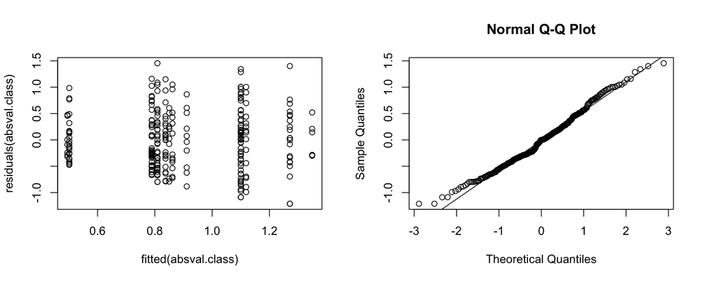

```r
# Absolute valence, cluster:

par(mfrow = c(1, 2))
plot(fitted(absval.class), residuals(absval.class))
qqnorm(residuals(absval.class)); qqline(residuals(absval.class))
```

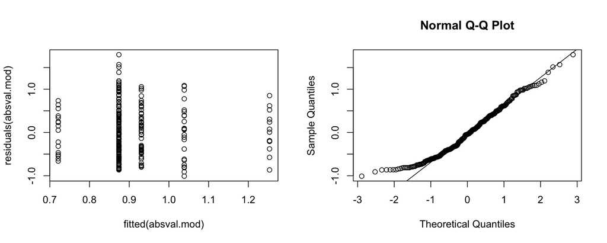

```r
# Absolute valence, categorical:

par(mfrow = c(1, 2))
plot(fitted(absval.mod), residuals(absval.mod))
qqnorm(residuals(absval.mod)); qqline(residuals(absval.mod))
```

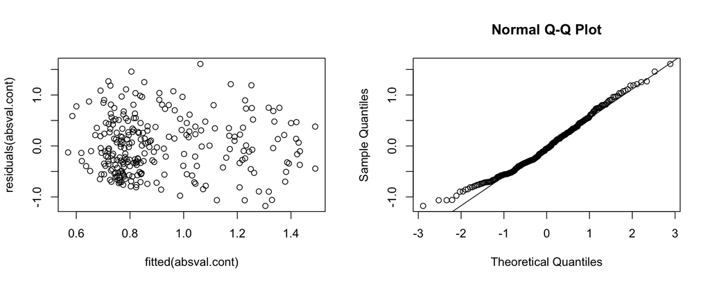

```r
# Absolute valence, continuous:

par(mfrow = c(1, 2))
plot(fitted(absval.cont), residuals(absval.cont))
qqnorm(residuals(absval.cont)); qqline(residuals(absval.cont))
```

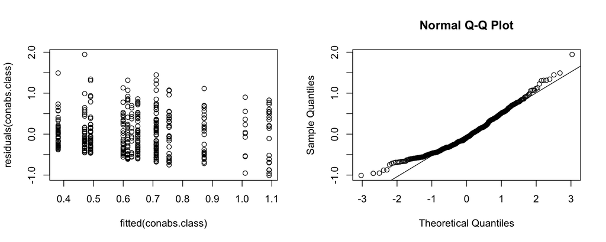

```r
# Context absolute valence, cluster:

par(mfrow = c(1, 2))
plot(fitted(conabs.class), residuals(conabs.class))
qqnorm(residuals(conabs.class)); qqline(residuals(conabs.class))
```

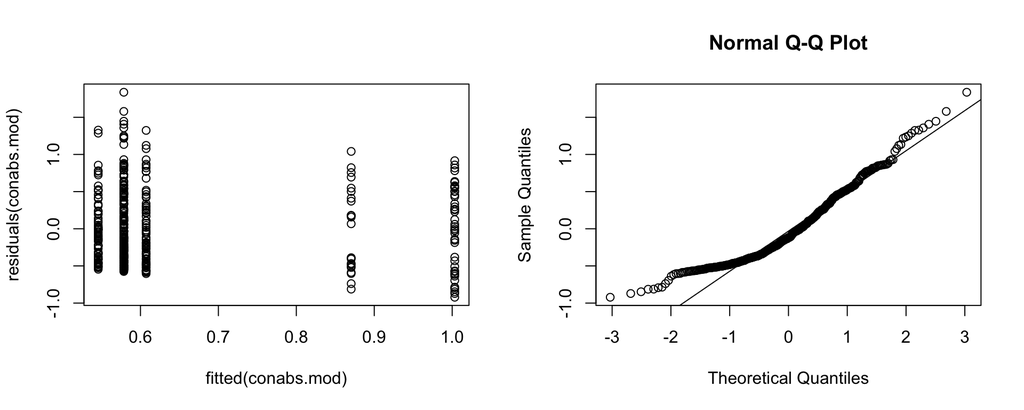

```r
# Context absolute valence, categorical:

par(mfrow = c(1, 2))
plot(fitted(conabs.mod), residuals(conabs.mod))
qqnorm(residuals(conabs.mod)); qqline(residuals(conabs.mod))
```

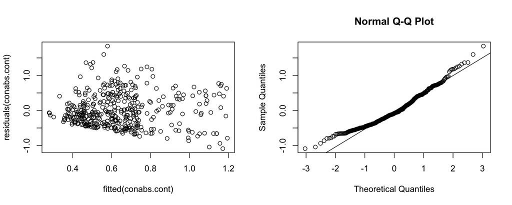

```r
# Context absolute valence, continuous:

par(mfrow = c(1, 2))
plot(fitted(conabs.cont), residuals(conabs.cont))
qqnorm(residuals(conabs.cont)); qqline(residuals(conabs.cont))
```

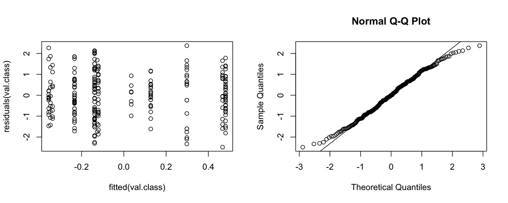

```r
# Valence, cluster:

par(mfrow = c(1, 2))
plot(fitted(val.class), residuals(val.class))
qqnorm(residuals(val.class)); qqline(residuals(val.class))
```

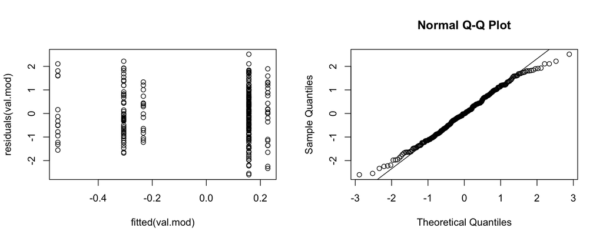

```r
# Valence, categorical:

par(mfrow = c(1, 2))
plot(fitted(val.mod), residuals(val.mod))
qqnorm(residuals(val.mod)); qqline(residuals(val.mod))
```

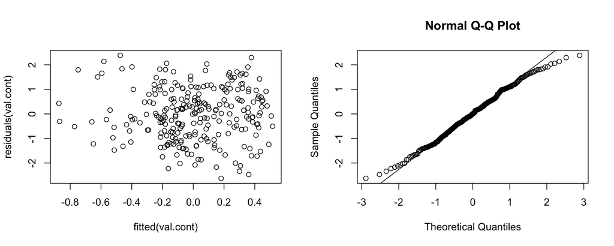

```r
# Valence, continuous:

par(mfrow = c(1, 2))
plot(fitted(val.cont), residuals(val.cont))
qqnorm(residuals(val.cont)); qqline(residuals(val.cont))
```

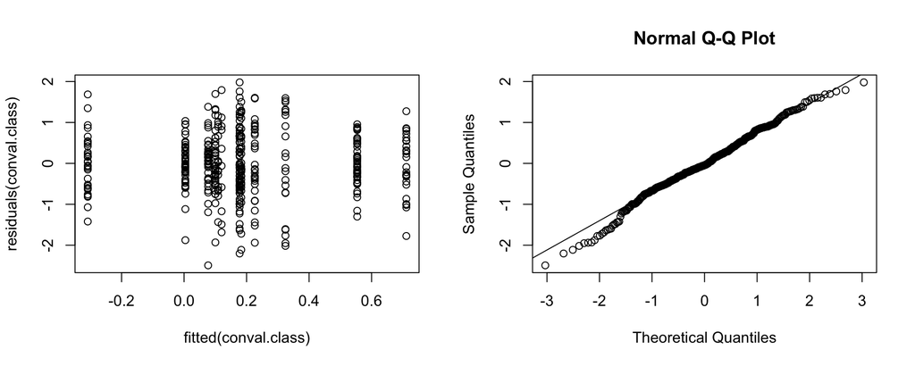

```r
# Context valence, cluster:

par(mfrow = c(1, 2))
plot(fitted(conval.class), residuals(conval.class))
qqnorm(residuals(conval.class)); qqline(residuals(conval.class))
```

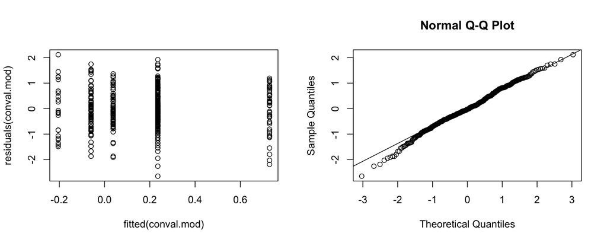

```r
# Context valence, categorical:

par(mfrow = c(1, 2))
plot(fitted(conval.mod), residuals(conval.mod))
qqnorm(residuals(conval.mod)); qqline(residuals(conval.mod))
```

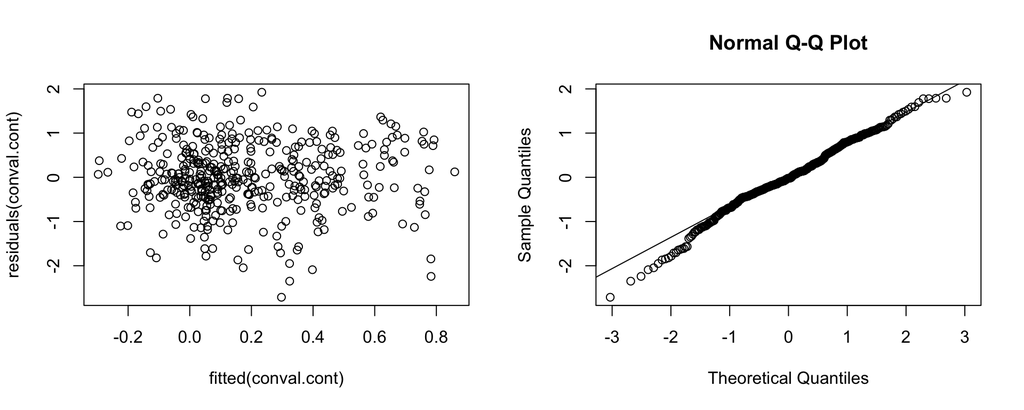

```r
# Context valence, continuous:

par(mfrow = c(1, 2))
plot(fitted(conval.cont), residuals(conval.cont))
qqnorm(residuals(conval.cont)); qqline(residuals(conval.cont))
```

This completes the analyses presented in Chapter 16.